# Udacity - Data Analysis Nanodegree

## Project 5 - Identify Fraud from Enron Email

#### Author: Andreas Huber

## Preparation of Input/Output Files from Investigation for further Analysis

```python
import pandas as pd
from pandas.tools.plotting import scatter_matrix
import numpy as np
from os import listdir
from os.path import isfile, join
import math
import matplotlib.pyplot as plt
%matplotlib inline
import scipy.stats  as stats

# Data file containing original as well as newly created features
df_data = pd.read_csv("full_data.csv")
df_feature_scores = pd.read_csv("feature_scores.csv")
df_results_auto_selected_features_1 = pd.read_csv("results_auto_selected_features_1.csv")
df_feature_classifier_selection_step_1 = pd.read_csv("feature_classifier_selection_step_1.csv")
df_adaboost_step_2 = pd.read_csv("adaboost_step_2.csv")
df_comp_feature_scaling_adaboost_step_2 = pd.read_csv("comp_feature_scaling_adaboost.csv")
df_final_results = pd.read_csv("final_results.csv")
```

## QUESTION 1:

Summarize for us the goal of this project and how machine learning is useful in trying to accomplish it. As part of your answer, give some background on the dataset and how it can be used to answer the project question. Were there any outliers in the data when you got it, and how did you handle those? [relevant rubric items: “data exploration”, “outlier investigation”]

### ANSWER:

The goal of the project is to identify POIs (person of interest) of the Enron fraud case by analysing a data set consisting of email data of numerous Enron employees as well as financial information about the employees. Some of the POIs have already been identified and those have been labelled accordingly in the dataset already. For our investigations, this is relevant as it allows us to use supervised learning algorithms for identifying further POIs in the dataset. The available email and financial data will be used to training and test different learning algorithms as well as different configurations of the complete test cases (algorithm and data). Two considerable outliers have been removed from the dataset before further performing analysis. Those have been identified doing a qualitative analysis of the data, namely taking a look at the data in an appropriate application (eg. Excel) and searching manually for data which seems to be inappropriate for using it as a base for further investigations. Once identified, that data can be removed using Python code.

### Furhter information about the original data set:

```python
print "Total Number of Data Points / Features: "
print "Employees              - " + str(df_data.shape[0])
print "Features per Employee  -  " + str(df_data.shape[1])
```

```
Total Number of Data Points / Features:
Employees              - 144
Features per Employee  -  31
```

```python
print "Features of the data set and the corresponding number of NaN values:"
df_data.isnull().sum().sort_values(ascending = 0)
```

```
Features of the data set and the corresponding number of NaN values:
```

```
loan_advances                 141
director_fees                 128
restricted_stock_deferred     127
deferral_payments             106
deferred_income                96
long_term_incentive            79
bonus                          63
bonus_log                      63
to_messages                    58
shared_receipt_with_poi        58
from_messages                  58
from_poi_to_this_person        58
from_this_person_to_poi        58
other                          53
expenses_log                   50
expenses                       50
salary                         50
salary_log                     50
exercised_stock_options        43
restricted_stock               35
email_address                  33
total_payments                 21
total_stock_value              19
expenses_squared                0
total_poi_related_messages      0
poi                             0
salary_squared                  0
bonus_squared                   0
total_messages                  0
total_poi_message_ratio         0
name                            0
dtype: int64
```

The above list includes both, original features of the data set, as well as newly created features. In general, newly created features based on financial data can be identified by the suffixes _log and _squared. New features created based on the messaging data are total_messages, total_poi_related_messages, and total_poi_message_ratio. New financial features are based upon salary, expenses and bonus only (as those are chosen for the final data set used to train the classifier). New messaging features are constant, means not depending on the selection of messaging features. Obviously, new features built on financial features, very likely show the same number of NaN values.

One example of a newly created feature is total_poi_related_messages. This feature shows the total number of touchpoints a person has with a POI. Means it combines the number of messages sent from a POI to that person, the number of messages a that person sent to a POI, and the number of messages where both, that person and the POI, have received the same message. The idea was to find a number describing a kind of aggregated view of all availalbe message related data for a person in relation to POIs.

```python
nrPois = df_data[df_data.poi == True].poi.count()
nrNoPois = df_data[df_data.poi == False].poi.count()
partPois = float((100/(float(nrPois+nrNoPois))))*nrPois

print "Percentage of POIs in the dataset: " + str(partPois) + " %"
print "POIs/Non POIs in the data set:"
print "    POIs      -   " + str(nrPois)
print "    Non POIs  -  " + str(nrNoPois)
```

```
Percentage of POIs in the dataset: 12.5 %
POIs/Non POIs in the data set:
    POIs      -   18
    Non POIs  -  126
```

### Further investigations of the features used for the classifier

Eventhough some of the features used for training the classifier, had a relative high number of NaN values, the still qualified for using them. For example, features bonus and expenses can naturally have some NaN values as not all of the employess might have gotten bonuses or might have had expenses. More sure, all of the employees should have gotten a salary. However, there were 50 NaN values in the salary data.

For the messaging data a similar situation applies. It might be that NaN values for from_poi_to_this_person and from_this_person_to_poi are just naturally there because no communication from or to POIs has happened.

In the following some investigations of the features I used as a base for tuning the final classifier are investigated in a bit more detail. The selection process to come up with those 5 features is explained in more details later in the report.

#### Feature "Bonus"

```python
df_data.bonus.describe()
```

```
count         81.000000
mean     1201773.074074
std      1441679.438330
min        70000.000000
25%       425000.000000
50%       750000.000000
75%      1200000.000000
max      8000000.000000
Name: bonus, dtype: float64
```

```python
print "Number of NaN values in data:          " + str(df_data["bonus"].isnull().sum())
print "Number of POIs in NaN values in data:   " + str(df_data[df_data["bonus"].isnull()]["poi"].sum())
```

```
Number of NaN values in data:          63
Number of POIs in NaN values in data:   2
```

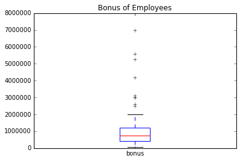

```python
pd.DataFrame(df_data.bonus).plot(kind='box', return_type='axes', title='Bonus of Employees')
```

```python
uO = df_data.bonus.quantile(0.75)+1.5*(df_data.bonus.quantile(0.75)-df_data.bonus.quantile(0.25))
lO = df_data.bonus.quantile(0.25)-1.5*(df_data.bonus.quantile(0.75)-df_data.bonus.quantile(0.25))
print "Number of POIs/Non POIs in the upper Outliers:"
print "POIs:      " + str(df_data[df_data.bonus > uO].groupby("poi").count().name[1])
print "Non POIs:  " + str(df_data[df_data.bonus > uO].groupby("poi").count().name[0])
print
print "No Outliers on the lower side."
```

```
Number of POIs/Non POIs in the upper Outliers:
POIs:      4
Non POIs:  6

No Outliers on the lower side.
```

We can see some real significant outliers when taking a look at the *bonus* data. The outliers are on the higher spectrum and make up 10/144 of the data. Interesting to see is that 40 % of the outliers are POIs.

#### Feature "Directory Fees"

```python
df_data.director_fees.describe()
```

```
count        16.000000
mean      89822.875000
std       41112.700735
min        3285.000000
25%       83674.500000
50%      106164.500000
75%      112815.000000
max      137864.000000
Name: director_fees, dtype: float64
```

```python
print "Number of NaN values in data:          " + str(df_data["director_fees"].isnull().sum())
print "Number of POIs in NaN values in data:   " + str(df_data[df_data["director_fees"].isnull()]["poi"].sum())
```

```
Number of NaN values in data:          128
Number of POIs in NaN values in data:   18
```

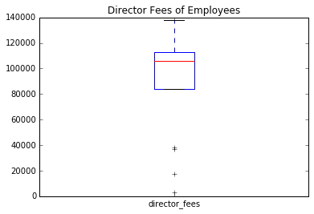

```python
pd.DataFrame(df_data.director_fees).plot(kind='box', return_type='axes', title='Director Fees of Employees')
```

```python
print "Number of POIs/Non POIs in the Outliers:"
print "POIs:     " + str(0)
print "Non POIs: " + str(df_data[df_data.director_fees < 40000].groupby("poi").count().name[0])
```

```
Number of POIs/Non POIs in the Outliers:
POIs:     0
Non POIs: 4
```

```python
df_data[df_data.director_fees < lO].groupby("poi").count().name
```

```
poi
False    4
Name: name, dtype: int64
```

```python
uO = df_data.director_fees.quantile(0.75)+1.5*(df_data.director_fees.quantile(0.75)-df_data.director_fees.quantile(0.25))
lO = df_data.director_fees.quantile(0.25)-1.5*(df_data.director_fees.quantile(0.75)-df_data.director_fees.quantile(0.25))
print "No Outliers on the higher side."
print
print "Number of POIs/Non POIs in the lower Outliers:"
print "POIs:      0"
print "Non POIs:  " + str(df_data[df_data.director_fees < lO].groupby("poi").count().name[0])
```

```
No Outliers on the higher side.

Number of POIs/Non POIs in the lower Outliers:
POIs:      0
Non POIs:  4
```

#### Feature "Expenses"

```python
df_data.expenses.describe()
```

```
count        94.000000
mean      54192.010638
std       46108.377454
min         148.000000
25%       22479.000000
50%       46547.500000
75%       78408.500000
max      228763.000000
Name: expenses, dtype: float64
```

```python
print "Number of NaN values in data:           " + str(df_data["expenses"].isnull().sum())
print "Number of POIs in NaN values in data:    " + str(df_data[df_data["expenses"].isnull()]["poi"].sum())
```

```
Number of NaN values in data:           50
Number of POIs in NaN values in data:    0
```

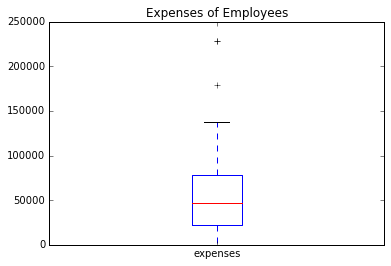

```python
pd.DataFrame(df_data.expenses).plot(kind='box', return_type='axes', title='Expenses of Employees')
```

```python
uO = df_data.expenses.quantile(0.75)+1.5*(df_data.expenses.quantile(0.75)-df_data.expenses.quantile(0.25))
lO = df_data.expenses.quantile(0.25)-1.5*(df_data.expenses.quantile(0.75)-df_data.expenses.quantile(0.25))
print "Number of POIs/Non POIs in the higher Outliers:"
print "POIs:      0"
print "Non POIs:  " + str(df_data[df_data.expenses > uO].groupby("poi").count().name[0])
print
print "No Outliers on the lower side."
```

```
Number of POIs/Non POIs in the higher Outliers:
POIs:      0
Non POIs:  3

No Outliers on the lower side.
```

In total there are 3 outliers in the *expenses* data. However, no POIs are part of that outliers.

#### Feature "total_payments"

```python
df_data.total_payments.describe()
```

```
count    1.230000e+02
mean     2.641806e+06
std      9.524694e+06
min      1.480000e+02
25%      3.969340e+05
50%      1.101393e+06
75%      2.087530e+06
max      1.035598e+08
Name: total_payments, dtype: float64
```

```python
print "Number of NaN values in data: "
df_data["total_payments"].isnull().sum()
```

```
Number of NaN values in data:
```

```
21
```

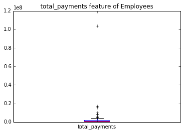

```python
pd.DataFrame(df_data.total_payments).plot(kind='box', return_type='axes',
                                                   title='total_payments feature of Employees')
```

```python
uO = df_data.total_payments.quantile(0.75)+1.5*(df_data.total_payments.quantile(0.75)-df_data.total_payments.quantile(0.25))
lO = df_data.total_payments.quantile(0.25)-1.5*(df_data.total_payments.quantile(0.75)-df_data.total_payments.quantile(0.25))
print "Number of POIs/Non POIs in the upper Outliers:"
print "POIs:      " + str(df_data[df_data.total_payments > uO].groupby("poi").count().name[1])
print "Non POIs:  " + str(df_data[df_data.total_payments > uO].groupby("poi").count().name[0])
print
print "No Outliers on the lower side."
```

```
Number of POIs/Non POIs in the upper Outliers:
POIs:      4
Non POIs:  6

No Outliers on the lower side.
```

```python
print "Name:           "
print df_data[df_data.total_payments > 100000000].name
print "total_payments: "
print df_data[df_data.total_payments > 100000000].total_payments
print "poi:            "
print df_data[df_data.total_payments > 100000000].poi
```

```
Name:
79    LAY KENNETH L
Name: name, dtype: object
total_payments:
79    103559793
Name: total_payments, dtype: float64
poi:
79    True
Name: poi, dtype: bool
```

#### Feature "from_poi_to_this_person"

```python
df_data.from_poi_to_this_person.describe()
```

```
count     86.000000
mean      64.895349
std       86.979244
min        0.000000
25%       10.000000
50%       35.000000
75%       72.250000
max      528.000000
Name: from_poi_to_this_person, dtype: float64
```

```python
print "Number of NaN values in data:         " + str(df_data["from_poi_to_this_person"].isnull().sum())
print "Number of POIs in NaN values in data:  " + str(df_data[df_data["from_poi_to_this_person"].isnull()]["poi"].sum())
```

```
Number of NaN values in data:         58
Number of POIs in NaN values in data:  4
```

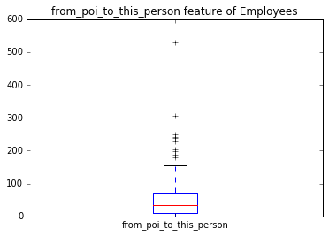

```python
pd.DataFrame(df_data.from_poi_to_this_person).plot(kind='box', return_type='axes',
                                                   title='from_poi_to_this_person feature of Employees')
```

```python
print "Number of POIs/Non POIs in the Outliers:"
print "POIs:     0"
print "Non POIs: " + str(df_data[df_data.from_poi_to_this_person > 150].groupby("poi").count().name[0])
```

```
Number of POIs/Non POIs in the Outliers:
POIs:     0
Non POIs: 9
```

```python
uO = df_data.from_poi_to_this_person.quantile(0.75)+1.5*(df_data.from_poi_to_this_person.quantile(0.75)-df_data.from_poi_to_this_person.quantile(0.25))
lO = df_data.from_poi_to_this_person.quantile(0.25)-1.5*(df_data.from_poi_to_this_person.quantile(0.75)-df_data.from_poi_to_this_person.quantile(0.25))
print "Number of POIs/Non POIs in the higher Outliers:"
print "POIs:      " + str(df_data[df_data.from_poi_to_this_person > uO].groupby("poi").count().name[1])
print "Non POIs:  " + str(df_data[df_data.from_poi_to_this_person > uO].groupby("poi").count().name[0])
print
print "No Outliers on the lower side."
```

```
Number of POIs/Non POIs in the higher Outliers:
POIs:      3
Non POIs:  8

No Outliers on the lower side.
```

### QUESTION 2:

What features did you end up using in your POI identifier, and what selection process did you use to pick them? Did you have to do any scaling? Why or why not? As part of the assignment, you should attempt to engineer your own feature that does not come ready-made in the dataset -- explain what feature you tried to make, and the rationale behind it. (You do not necessarily have to use it in the final analysis, only engineer and test it.) In your feature selection step, if you used an algorithm like a decision tree, please also give the feature importances of the features that you use, and if you used an automated feature selection function like SelectKBest, please report the feature scores and reasons for your choice of parameter values. [relevant rubric items: “create new features”, “properly scale features”, “intelligently select feature”]

#### ANSWER:

From the email data the employees email address has been removed from the data as it does not make sense to use it for any investigations, basically it is a unique identifier for a person, but that's it.

My approach on the remaining features was changing over time. In a first attempt, the preparation of features was done using a PCA algorithm. No manual pre-exclusion of features was done. However, the programm allowed to define the number of features used for the learning process. Nevertheless, the automatic composition of the features based on a PCA algorithm was not sucessfully (as the result I was able to achieve did not satisfy the specification limits) and even using a univariate feature selection algorithm did not significantly improve the results. Finally, I had to change from an automatic, completely machine driven approach to a semi-manual one over time. I ended up using features which I have manually chosen based on their scores (SelectKBest) and importances (importances_ scores) in combination with human intuition and tested them using different classifiers. Finally was able to reach the requested results. More information about the different approaches follows below.

**First attempt**

From the financial data set non of the features have been removed manually, the approach was to apply a PCA (principal component analysis) algorithm to optimize the features for further downstream analysis with supervised learning classifiers.

Some of the financial data has been used as a base to create new features. Basically, the features process included a log as well as a square transformation of the data aiming to better visualize differences in the different values or identifying trend which are hidden in the raw data set. Further, some new KPIs for the email data have been created to even better understand the behaviour of POIs, especially their involvement in different email conversations. Eg. one feature provides information about all POI related messages of a specific person, an other one provides the relationship between the number all those POI related messages and all messages. Those new features target to further support analysis by providing a new views from different angles. All newly created features have been included into the features selection process performed by the PCA algorithm.

For performing the PCA, a list numbers of target parameters has been provided. The program was checking all the different possibilities and for each of the different options the different classifiers with different configurations were applied. The best performing configuration was picked at the end. Scores for the different configurations are provided as output in the program.

However, the approach of automatically selecting features has not been successfully. Even though I tried lots of different classifiers with various configurations, the classifiers have not been satisfying from a *precision* and *recall* perspective.

**Second attempt**

I reworked what I have done from an automatism perspective and created a program which was allowing for a more semi-automatical selection of the algorithm, its configuration, the number of features used and which features to be used. Following a manual selection of the features to be used for the classification, I needed some support to make my descision. Therefore I implemented a section to print the feature score based on a univariate feature selection algorithm, namely SelectKBest. Further, I included one section to print the importance of features for a specific algorithm. Based on that information, I was able to sort our useless features and concentrate on the important ones. By doing that, I was able to clearly increase the performance of the algorithms. The features I finally used have been already discussed as part of the first question.

A description of the steps for features selection and classifier tuning:

```
0) Automatic selection of best features based on SelectKBest algorithm. Result: Take a look at features_scores.csv to see how the different features have been rated by SelectKBest algorithm in combination with an ANOVA F-value function, as I found this to be a good function to use in case of a classification problem. However, when using the features proposed by SelectKBest, I did not get satisfying result. Therfore, I trashed this approach again and had to proceed as described in the next steps.

1) Based on some basic tests (using the results of feature selection algorithm SelectKBest and the importance performance indicator as a guideline) combined with human intuition (eg. if it comes to fraud detection of employees, _bonus_ seems to be an interesting feature even before you prove the assumption by performing different tests). The goal of that step was to find the features which are going to be used for further tunig of the algorithm as well as the top classifiers. Result: Features - bonus, expenses, total_payments, director_fees, from_poi_to_this_person; Classifiers - AdaBoostClassifier, KNeighborsClassifier

2) Use the best performing algorithms (AdaBoostClassifier, KNeighborsClassifier) and find the best performing features (base for this are the result of step 1 - bonus, expenses, total_payments, director_fees, from_poi_to_this_person) and related options like considering newly created features and using PCA.
```

- not full scope of features has been used to figure out the best performing algortihm and setup

**Second attempt: Step 0**

Below you can see the ranking of the original features based on SelectKBest algorithm.

```python
pd.DataFrame(df_feature_scores[df_feature_scores.set == "ORIG"], columns=["ranking", "feature", "score"])
```

|  | ranking | feature | score |
| --- | --- | --- | --- |
| 0 | 1 | total_payments | 18.077028 |
| 1 | 2 | director_fees | 17.934003 |
| 2 | 3 | to_messages | 12.879507 |
| 3 | 4 | from_this_person_to_poi | 10.355194 |
| 4 | 5 | bonus | 10.093090 |
| 5 | 6 | deferral_payments | 8.126530 |
| 6 | 7 | from_messages | 7.978345 |
| 7 | 8 | other | 5.966579 |
| 8 | 9 | exercised_stock_options | 4.746047 |
| 9 | 10 | loan_advances | 3.303757 |
| 10 | 11 | shared_receipt_with_poi | 2.945261 |
| 11 | 12 | from_poi_to_this_person | 2.477487 |
| 12 | 13 | deferred_income | 1.755317 |
| 13 | 14 | restricted_stock_deferred | 1.059088 |
| 14 | 15 | salary | 0.288022 |
| 15 | 16 | expenses | 0.138933 |
| 16 | 17 | long_term_incentive | 0.126823 |
| 17 | 18 | poi | 0.099707 |
| 18 | 19 | restricted_stock | 0.074125 |

Using the 5 top features from above, the performance of the different algorithms (configuration selection was done automatically based on GridSearchCV) was as follows:

```python
df_results_auto_selected_features_1
```

|  | clf | features_scaled | features | accuracy | precision | recall | meet_spec | combined_recall_precision |
| --- | --- | --- | --- | --- | --- | --- | --- | --- |
| 0 | <class 'sklearn.neighbors.classification.KNeig... | scaled | ['poi', 'from_this_person_to_poi', 'to_message... | 0.814143 | 0.336591 | 0.3100 | True | 0.646591 |
| 1 | <class 'sklearn.tree.tree.DecisionTreeClassifi... | not scaled | ['poi', 'from_this_person_to_poi', 'to_message... | 0.782714 | 0.240279 | 0.2410 | False | 0.481279 |
| 2 | <class 'sklearn.naive_bayes.GaussianNB'> | scaled | ['poi', 'from_this_person_to_poi', 'to_message... | 0.671500 | 0.215956 | 0.4940 | False | 0.709956 |
| 3 | <class 'sklearn.ensemble.weight_boosting.AdaBo... | scaled | ['poi', 'from_this_person_to_poi', 'to_message... | 0.379786 | 0.157106 | 0.7655 | False | 0.922606 |
| 4 | <class 'sklearn.ensemble.forest.RandomForestCl... | not scaled | ['poi', 'from_this_person_to_poi', 'to_message... | 0.809714 | 0.268802 | 0.1930 | False | 0.461802 |
| 5 | <class 'sklearn.linear_model.logistic.Logistic... | scaled | ['poi', 'from_this_person_to_poi', 'to_message... | 0.709357 | 0.129875 | 0.1815 | False | 0.311375 |

Obviously, the performace was not very good, but still one of the algorithm in combination with the seleceted features was satisfying the requirements. Algorithm KNeighborsClassifier achieved more than 30 % precision and recall.

##### Second attempt: Step 1

Diving deeper into feature selection to achieve better result, I expanded the 5 top features from above (total_payments, director_fees, to_message, from_this_person_to_poi, bonus) with some more financial (salary, expenses) and messaging (from_poi_to_this_person, shared_receipt_with_poi) features which I expected to have a positive impact to the performance of the classifiers.

For those original features I tried various combinations to figure out good performing feature and related classifiers. The result can be seen in the table below which is showing the top 10 results. Complete data is availalbe in the attached file feature_classifier_selection_step_2.csv.

```python
top_performer_step_2 = pd.DataFrame(df_feature_classifier_selection_step_1[df_feature_classifier_selection_step_1
                                    .meet_specs == True]
                                    .sort_values(['combined_recall_precision'], ascending=[False]),
                        columns=['clf', 'precision', 'recall', 'combined_recall_precision','features','meet_specs'])
top_performer_step_2[:10]
```

|  | clf | precision | recall | combined_recall_precision | features | meet_specs |
| --- | --- | --- | --- | --- | --- | --- |
| 21 | <class 'sklearn.ensemble.weight_boosting.AdaBo... | 0.564544914 | 0.4745 | 1.039045 | ['poi', 'bonus', 'expenses'] | True |
| 22 | <class 'sklearn.ensemble.weight_boosting.AdaBo... | 0.543195935 | 0.481 | 1.024196 | ['poi', 'bonus', 'director_fees', 'expenses'] | True |
| 23 | <class 'sklearn.ensemble.weight_boosting.AdaBo... | 0.555819477 | 0.468 | 1.023819 | ['poi', 'bonus', 'director_fees', 'expenses', ... | True |
| 25 | <class 'sklearn.ensemble.weight_boosting.AdaBo... | 0.3908233 | 0.6005 | 0.991323 | ['poi', 'from_poi_to_this_person', 'from_this_... | True |
| 26 | <class 'sklearn.ensemble.weight_boosting.AdaBo... | 0.51577802 | 0.474 | 0.989778 | ['poi', 'from_poi_to_this_person', 'from_this_... | True |
| 28 | <class 'sklearn.neighbors.classification.KNeig... | 0.593067069 | 0.3935 | 0.986567 | ['poi', 'bonus', 'director_fees'] | True |
| 29 | <class 'sklearn.neighbors.classification.KNeig... | 0.593067069 | 0.3935 | 0.986567 | ['poi', 'bonus', 'director_fees'] | True |
| 30 | <class 'sklearn.neighbors.classification.KNeig... | 0.610324729 | 0.3665 | 0.976825 | ['poi', 'from_poi_to_this_person', 'to_message... | True |
| 32 | <class 'sklearn.neighbors.classification.KNeig... | 0.592201462 | 0.3645 | 0.956701 | ['poi', 'from_poi_to_this_person', 'bonus', 'd... | True |
| 33 | <class 'sklearn.ensemble.weight_boosting.AdaBo... | 0.483787957 | 0.47 | 0.953788 | ['poi', 'bonus', 'director_fees'] | True |

Note: Column meet*specs indicates if both, _precision* as well as *recall* are above the 0.3 limit. Column *combined_recall_precision* is summing up *precision* and *recall* value and serve as an indicator of the performance (clearly, this is a very simple way to track the performance as for example high balanced values for *precision* and *recall* might be something worthwhile too).

Further, one can notice, that AdaBoost as well as KNeighborsClassifier seem to be the top performing classifiers. For that reason, from here onwards I will concentrate on the best performing algorithm - AdaboostClassifier - only and try to improve the results. From a feature selection perspective, it seems like some specific features are key to good performance. I decided to pick the most appearing features of the top 10 results from above.

Those are:

```
1) 9 occurrences: _bonus_
2) 9 occurrences: _director_fees_
3) 7 occurrences: _expenses_
4) 4 occurrences: _from_poi_to_this_person_
5) 3 occurrences: _total_payments_
```

Best results are achieved by the below classifier and related configuration:

```
AdaBoostClassifier(algorithm='SAMME', base_estimator=None, learning_rate=1,
      n_estimators=3, random_state=None)
```

##### Second attempt: Step 2

Fine tune feature and classifier configuration.

**Scaled data, number of features used and newly created features**

Below you can see results based on different inputs ( feature scaling, PCA/no PCA, variations of top 5 features, with/without newly created features) which have been used when performing analysis with the finally chosen classifier.

*Feature Scaling & PCA:*

I also tried PCA in combination with Adaboost. PCA did not really increase the performance of the algorithm, in fact the results without PCA were in general better. Testing PCA for this case, I tried out different numbers of PCA components. In a below section you can find more information regarding tests and results.

As I stated above, I will further concentrate on AdaBoostClassifier and do some test with varying feature setups. Those are the columns in the above table which are important to understand the data which has been used for the different tests:

- **scenario_class**: indicates the kind of test scenario which was applied (more info below)
- **best estimator**: classifier and configuration
- **features_scaled**: if features are MinMax scaled or not
- **number of features**: including newly created features, this number get overruled by number in PCA column if there
- **precision** and **recall**: see description in question 6
- **orig data set**: if True, than non of the newly created features have been considered in the result.
- **create new message features**: have new message features been part of the data set
- **create new financial features**: have new financial features been part of the data set
- **PCA**: was a PCA used, if so a number is providing the number of features used
- **meet_specs**: indicates if both, precision and recall, are above 0.3. 1 = specs me, 0 = specs not met
- **performance**: values of precision plus value of recall

```python
pd.DataFrame(df_adaboost_step_2.sort_values(['performance'], ascending=[False]),
             columns=["scenario_class", "best estimator", "features_scaled", "number of features", "precision",
                                          "recall", "orig data set", "create_new_message_features",
                                          "create_new_finance_features", "PCA", "meet_specs", "performance"])
```

|  | scenario_class | best estimator | features_scaled | number of features | precision | recall | orig data set | create_new_message_features | create_new_finance_features | PCA | meet_specs | performance |
| --- | --- | --- | --- | --- | --- | --- | --- | --- | --- | --- | --- | --- |
| 10 | 3 | AdaBoostClassifier(algorithm='SAMME', base_est... | scaled | 5 | 0.562428 | 0.4865 | True | False | False | FALSE | 1 | 1.048928 |
| 8 | 3 | AdaBoostClassifier(algorithm='SAMME', base_est... | scaled | 5 | 0.555819 | 0.4680 | True | False | False | FALSE | 1 | 1.023819 |
| 12 | 3 | AdaBoostClassifier(algorithm='SAMME', base_est... | scaled | 5 | 0.537181 | 0.4840 | True | False | False | FALSE | 1 | 1.021181 |
| 0 | 1 | AdaBoostClassifier(algorithm='SAMME', base_est... | scaled | 6 | 0.531596 | 0.4795 | True | False | False | FALSE | 1 | 1.011096 |
| 4 | 2 | AdaBoostClassifier(algorithm='SAMME', base_est... | not scaled | 6 | 0.531596 | 0.4795 | True | False | False | FALSE | 1 | 1.011096 |
| 6 | 2 | AdaBoostClassifier(algorithm='SAMME', base_est... | not scaled | 14 | 0.527123 | 0.4810 | False | False | True | FALSE | 1 | 1.008123 |
| 2 | 1 | AdaBoostClassifier(algorithm='SAMME', base_est... | scaled | 14 | 0.522331 | 0.4795 | False | False | True | FALSE | 1 | 1.001831 |
| 5 | 2 | AdaBoostClassifier(algorithm='SAMME', base_est... | not scaled | 9 | 0.472920 | 0.4235 | False | True | False | FALSE | 1 | 0.896420 |
| 1 | 1 | AdaBoostClassifier(algorithm='SAMME', base_est... | scaled | 9 | 0.472920 | 0.4235 | False | True | False | FALSE | 1 | 0.896420 |
| 3 | 1 | AdaBoostClassifier(algorithm='SAMME', base_est... | scaled | 17 | 0.468026 | 0.4245 | False | True | True | FALSE | 1 | 0.892526 |
| 7 | 2 | AdaBoostClassifier(algorithm='SAMME', base_est... | not scaled | 17 | 0.467290 | 0.4250 | False | True | True | FALSE | 1 | 0.892290 |
| 9 | 3 | AdaBoostClassifier(algorithm='SAMME', base_est... | scaled | 5 | 0.247119 | 0.2895 | True | False | False | FALSE | 0 | 0.536619 |
| 13 | 4 | AdaBoostClassifier(algorithm='SAMME', base_est... | scaled | 17 | 0.285156 | 0.1825 | False | True | True | 2 | 0 | 0.467656 |
| 17 | 4 | AdaBoostClassifier(algorithm='SAMME', base_est... | scaled | 17 | 0.332921 | 0.1345 | False | True | True | 6 | 0 | 0.467421 |
| 18 | 4 | AdaBoostClassifier(algorithm='SAMME', base_est... | scaled | 17 | 0.328916 | 0.1365 | False | True | True | 7 | 0 | 0.465416 |
| 14 | 4 | AdaBoostClassifier(algorithm='SAMME', base_est... | scaled | 17 | 0.278049 | 0.0570 | False | True | True | 3 | 0 | 0.335049 |
| 15 | 4 | AdaBoostClassifier(algorithm='SAMME', base_est... | scaled | 17 | 0.258503 | 0.0570 | False | True | True | 4 | 0 | 0.315503 |
| 16 | 4 | AdaBoostClassifier(algorithm='SAMME', base_est... | scaled | 17 | 0.258503 | 0.0570 | False | True | True | 5 | 0 | 0.315503 |
| 11 | 3 | AdaBoostClassifier(algorithm='SAMME', base_est... | scaled | 5 | 0.160473 | 0.0475 | True | False | False | FALSE | 0 | 0.207973 |

The above table also provides information about different parameters (PCA, feature scaling, features selection,...) of tests using Adaboost with different setups.

Explaination of scenarios:

**Comparision PCA / No PCA**

As we can see in above results and below summary of results, the performance of AdaboostClassifier varies a lot depending on the usage of PCA. In our case PCA did clearly impair the results.

```python
print "Impact of using PCA on the results:"
print "----------------------------------------------------------------------------"
print "Results without not using PCA"
print "Percentage of results passing specification limits: " + \
            str(100*df_adaboost_step_2[df_adaboost_step_2.PCA == "FALSE"].meet_specs.mean()) + " %"
print "Average performance of results: " + \
            str(100*df_adaboost_step_2[df_adaboost_step_2.PCA == "FALSE"].performance.mean())

print "----------------------------------------------------------------------------"
print "Results without using PCA"
print "Percentage of results passing specification limits: " + \
            str(100*df_adaboost_step_2[df_adaboost_step_2.PCA != "FALSE"].meet_specs.mean()) + " %"
print "Average performance of results: " + \
            str(100*df_adaboost_step_2[df_adaboost_step_2.PCA != "FALSE"].performance.mean())
```

```
Impact of using PCA on the results:
----------------------------------------------------------------------------
Results without not using PCA
Percentage of results passing specification limits: 84.6153846154 %
Average performance of results: 88.0640309538
----------------------------------------------------------------------------
Results without using PCA
Percentage of results passing specification limits: 0.0 %
Average performance of results: 39.44247145
```

**Feature Scaling**

```python
print "Impact of using Features Scaling on the results:"
print "----------------------------------------------------------------------------"
print "Results without not using PCA"
print "Percentage of results passing specification limits: " + \
            str(100*df_adaboost_step_2[df_adaboost_step_2.features_scaled == "scaled"].meet_specs.mean()) + " %"
print "Average performance of results: " + \
            str(100*df_adaboost_step_2[df_adaboost_step_2.features_scaled == "scaled"].performance.mean())

print "----------------------------------------------------------------------------"
print "Results without using PCA"
print "Percentage of results passing specification limits: " + \
            str(100*df_adaboost_step_2[df_adaboost_step_2.features_scaled == "not scaled"].meet_specs.mean()) + " %"
print "Average performance of results: " + \
            str(100*df_adaboost_step_2[df_adaboost_step_2.features_scaled == "not scaled"].performance.mean())
```

```
Impact of using Features Scaling on the results:
----------------------------------------------------------------------------
Results without not using PCA
Percentage of results passing specification limits: 46.6666666667 %
Average performance of results: 66.7129513
----------------------------------------------------------------------------
Results without using PCA
Percentage of results passing specification limits: 100.0 %
Average performance of results: 95.1982404
```

Below, you can see a direct comparison of results. In fact, some of the test resulted in the exact same result. Some of the results had really minor deviations depending on the usage of feature scaling.

```python
pd.DataFrame(df_comp_feature_scaling_adaboost_step_2.sort_values(['performance', 'features_scaled'], ascending=[False, True]),
             columns=["best estimator", "features_scaled", "accurcy", "precision", "recall", "meet_specs", "performance"])
```

|  | best estimator | features_scaled | accurcy | precision | recall | meet_specs | performance |
| --- | --- | --- | --- | --- | --- | --- | --- |
| 4 | AdaBoostClassifier(algorithm='SAMME', base_est... | not scaled | NaN | 0.531596 | 0.4795 | 1 | 1.011096 |
| 0 | AdaBoostClassifier(algorithm='SAMME', base_est... | scaled | NaN | 0.531596 | 0.4795 | 1 | 1.011096 |
| 6 | AdaBoostClassifier(algorithm='SAMME', base_est... | not scaled | NaN | 0.527123 | 0.4810 | 1 | 1.008123 |
| 2 | AdaBoostClassifier(algorithm='SAMME', base_est... | scaled | NaN | 0.522331 | 0.4795 | 1 | 1.001831 |
| 5 | AdaBoostClassifier(algorithm='SAMME', base_est... | not scaled | NaN | 0.472920 | 0.4235 | 1 | 0.896420 |
| 1 | AdaBoostClassifier(algorithm='SAMME', base_est... | scaled | NaN | 0.472920 | 0.4235 | 1 | 0.896420 |
| 3 | AdaBoostClassifier(algorithm='SAMME', base_est... | scaled | NaN | 0.468026 | 0.4245 | 1 | 0.892526 |
| 7 | AdaBoostClassifier(algorithm='SAMME', base_est... | not scaled | NaN | 0.467290 | 0.4250 | 1 | 0.892290 |

### QUESTION 3:

What algorithm did you end up using? What other one(s) did you try? How did model performance differ between algorithms? [relevant rubric item: “pick an algorithm”]

#### ANSWER:

Criteria to select the best algorithm:

- Precision (the higher the better)
- Accuracy (the higher the better)
- Recall (the higher the better)
- Number of features (the lower the better)

Throught the investigations, I have tried all different algorithms which are available for testing in the poi.py file. This includes GaussianNB, KNeighborsClassifier, AdaBoostClassifier, RandomForestClassifier and DecisionTreeClassifier.

Based on the test results from above, I identified the below algorithm and related configuration performing the best results.

```
AdaBoostClassifier(algorithm='SAMME', base_estimator=None, learning_rate=1,
      n_estimators=3, random_state=None)
```

However, I picked up the above configuration of AdaboostClassifier and manually changed different parameters (basically base_estimator and learning_rate) to see if I can even achieve better results and approve the performance. Finally, I did find a better configuration and so the final algorithm and it's configuration is the following.

```
AdaBoostClassifier(algorithm='SAMME', base_estimator=None, learning_rate=1.5,
      n_estimators=3, random_state=None)
```

- **Algorithm: AdaBoostClassifier**
- Parameters: {'n_estimators'=3, 'algorithm'='SAMME', 'learning_rate'=1.5}
- Apply PCA: False
- Number of Features: 5
- Features Scaled: True (but in fact, that should not matter)
- Test size: 20 %

Here the result of tester.py with the selected configuration and data:

```
AdaBoostClassifier(algorithm='SAMME', base_estimator=None, learning_rate=1.5,
      n_estimators=3, random_state=None)
Accuracy: 0.87723    Precision: 0.63557    Recall: 0.47350    F1: 0.54269    F2: 0.49895
Total predictions: 13000    True positives:  947    False positives:  543    False negatives: 1053    True negatives: 10457
```

##### Final Result using above Classifier

```python
pd.DataFrame(df_final_results,
             columns=["clf", "features_scaled", "number of features",
                     "accuracy", "precision", "recall", "performance"])
```

|  | clf | features_scaled | number of features | accuracy | precision | recall | performance |
| --- | --- | --- | --- | --- | --- | --- | --- |
| 0 | <class 'sklearn.ensemble.weight_boosting.AdaBo... | scaled | 5 | 0.877231 | 0.63557 | 0.4735 | 1.10907 |

Between, the algorithms itself as well as it's configuration, the performance of the algorithms were varying a lot. With the program I created in poi.py I was able to realivley easy switch classifiers and to try lot's of different configurations for each classifier. See below a excerpt of the program code which shows how I defined the different classifiers:

```
#gl_clf_list = [
#[1, GaussianNB,
#    {},
#    "scaled"]
#[2, SVC,
#    {'kernel': ('linear', 'rbf')}, # - 'rbf'
#     "scaled"]
#[3, LogisticRegression,
#    {"C": [1], # - 10, 10 ** 2, 10000, 1, 0.1, 0.2, 0.5, 100, 1000
#     "tol": [0.5], # - , 10 ** -10, 10 ** -5
#     "multi_class": ('ovr', 'multinomial'),
#     "solver": ('sag', 'lbfgs')}, # 'newton-cg', 'lbfgs', 'liblinear', 'sag'
#     "not scaled"]
#[4, KNeighborsClassifier, # almost there
#    {"n_neighbors":[2], # - 2, 3, 4, 5, 7, 10 # increasing the number increases the precision
#     "p":[3], # 2, 3, 4
#     "algorithm": ('auto','ball_tree','kd_tree','brute'),
#     "leaf_size": [5],
#     "weights": ('uniform', 'distance')},
#     "scaled"]
#[5, DecisionTreeClassifier,
#    {"min_samples_split":[5]}, # - 4, 5, 7,
#     "not scaled"]
[6, AdaBoostClassifier,
    {"n_estimators":[3], # 3, 5, 10, 30, 40, 50, 60, 70],
     "algorithm": ['SAMME'], # - 'SAMME', 'SAMME.R'
     "learning_rate": [1.5]},
     "scaled"]
#,[7, RandomForestClassifier,
#    {"n_estimators":[10], # - 3, 5, 4, 7, 10, 15, 20
#     "criterion": ('gini', 'entropy')},
#     "not scaled"]
]
```

As explained already, in a first try I wanted the program to automatically select the best performing algorithm with the best performing configuration. However, that was not successfully as there was a deviation between the results when training and testing the algorithm to the results which have been delivered by tester.py.

What you can see above is code I used for the second try, where I tested algorithms in a more semi-automatic approach and with more specific configuration. Finally, I was successful using that approach.

The code in poi.py reflects what has been done in the second try when manually finding out the best configuration or AdaboostClassifier (still the code itself tells a bit of a story of the process and even artifacts of earlier phases might be in).

### QUESTION 4:

What does it mean to tune the parameters of an algorithm, and what can happen if you donât do this well? How did you tune the parameters of your particular algorithm? (Some algorithms do not have parameters that you need to tune -- if this is the case for the one you picked, identify and briefly explain how you would have done it for the model that was not your final choice or a different model that does utilize parameter tuning, e.g. a decision tree classifier).

#### ANSWER:

Tuning of an algorithm is key to get the best performance out of it. Wrongly set parameters can negatively impact accuracy, precision, recall of the resulting classifier.

For this program in a first step I used GridSearchCV to pick the best algortithm and configuration for it, based on a list of different input values for the available parameters.

### QUESTION 5:

What is validation, and whatâs a classic mistake you can make if you do it wrong? How did you validate your analysis?

#### ANSWER:

Validation means to test your algorithm after you configured and trained it. A good approach for the overall process is:

```
1) split your data into train and test data
2) do a PCA based on your training features (fit, transform)
3) pick, configure and train your classifier (use the PCA transformed train data)
4) transform your test data (for validation) using PCA
5) predict your results based on the test data
6) get relevant information about the KPIs (accuracy,..)
```

To get better validation results, specific approaches have been developed to support this process. An example for such an approach are cross validation algorithms. When using cross validation, the data set gets split into training and test sets to simulate how the model will behave once it starts predicting on new data.

### QUESTION 6:

Give at least 2 evaluation metrics and your average performance for each of them. Explain an interpretation of your metrics that says something human-understandable about your algorithm’s performance.

**Recall**: Out of all the items that are truly positive, how many are correctly classified as positive. How many positive items were recalled from the data set. In other words, how good is the algorithm in recognizing items which are actually belonging to a specific class. For example: How strong is the algorithm in recognizing that "BOWEN JR RAYMOND M" is a POI and put him into the POI class.

**Prevision**: Out of all the items labeled as positive how many truly belong to the positive class. In other words, how good is the algorithm in terms of correct class assignment. For example: What is the proportion of POI's in the POI class considering all items which have been identified and assigned to the POI class by the algorithm.

A common mistake which can be made in the validation phase is using the same data which was earlier used for training the classifier, for validating it. Obviously, that is not a valid validation case as training data and validation data have to be different.

##### Validation used in the project

StratifiedShuffleSplit in combination with GridSearchCV have been used in poi.py to find out the best configuration for an algorithm. The reason for using StratifiedShuffleSplit was the relatively low number of training and testing data.

Also tester.py used StratifiedShuffleSplit. I have changed the source code of tester.py a bit to get metrics of tests returned to where the function *test_classifier* is called, to be afterwards able to store and compare the results.

StratifiedShuffleSplit algorithm shuffles the data around before it gets split. The number of such shuffle/split operations can be provided as a parameter to the algorithm. Further test split between test and training data can be defined as well as a pseudo-random number generator state used for random sampling.